# **LOAN DEFAULT PREDICTION: A BINARY CLASSIFICATION APPROACH**

```
Fitting 5 folds for each of 5 candidates, totalling 25 fits
```

```
=== LASSO Logistic Regression (L1) CV results ===
Best params: {'C': 10}
Best mean CV F1: 0.7598371366211882
```

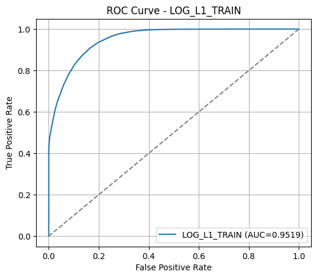

```
ROC-AUC (LOG_L1_TRAIN): 0.9519
```

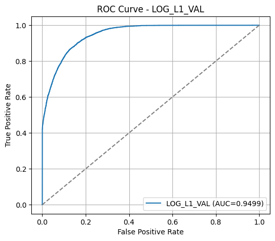

```
ROC-AUC (LOG_L1_VAL): 0.9499

====================== LOG_L1 RESULTS ======================

--- TRAIN ---
ROC-AUC: 0.9519
Recall:  0.8759
F1:      0.7632
```

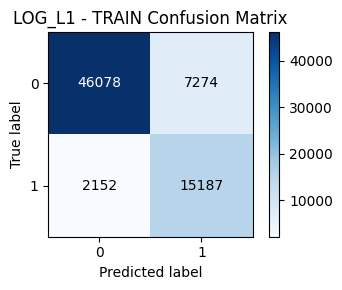

```
--- VAL ---
ROC-AUC: 0.9499
Recall:  0.8732
F1:      0.7628
```

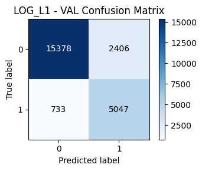

```python
# 3. LASSO LOGISTIC (L1) with class weights
lasso_base = LogisticRegression(
    class_weight=class_weights,
    max_iter=1000,
    solver="saga",     # supports L1 and large datasets
    penalty="l1"
)

lasso_param_grid = {
    "C": [0.001, 0.01, 0.1, 1, 10]
}

grid_lasso = GridSearchCV(
    estimator=lasso_base,
    param_grid=lasso_param_grid,
    scoring="f1",
    cv=cv,
    n_jobs=-1,
    verbose=1
)

# Fit ONLY on training set
grid_lasso.fit(Xs_train, y_train_new)

print("\n=== LASSO Logistic Regression (L1) CV results ===")
print("Best params:", grid_lasso.best_params_)
print("Best mean CV F1:", grid_lasso.best_score_)

# Best model
best_lasso = grid_lasso.best_estimator_

lasso_results = evaluate_model_full(
    model=best_lasso,
    X_train=Xs_train,
    y_train=y_train_new,
    X_val=Xs_val,
    y_val=y_val,
    model_name="LOG_L1"
)
```

```
Fitting 5 folds for each of 7 candidates, totalling 35 fits

=== Ridge Classifier CV results ===
Best params: {'alpha': 1}
Best mean CV F1: 0.7184002988110498
```

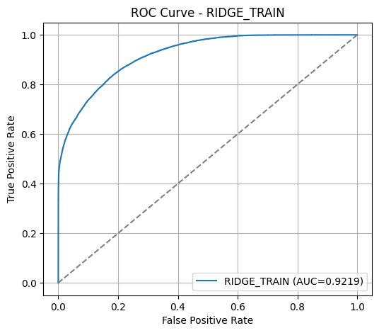

```
ROC-AUC (RIDGE_TRAIN): 0.9219
```

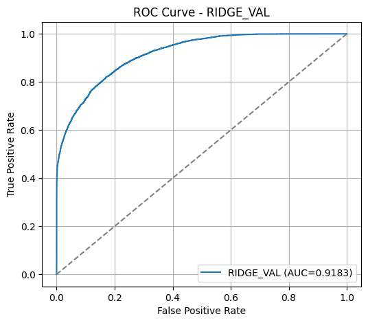

```
ROC-AUC (RIDGE_VAL): 0.9183

====================== RIDGE RESULTS ======================

--- TRAIN ---
ROC-AUC: 0.9219
Recall:  0.7638
F1:      0.7156
```

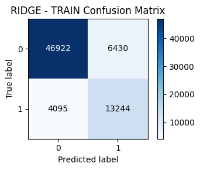

```
--- VAL ---
ROC-AUC: 0.9183
Recall:  0.7611
F1:      0.7166
```

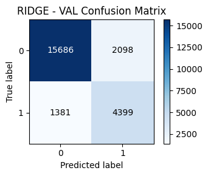

```python
# 4. RIDGE CLASSIFIER with class weights
ridge_base = RidgeClassifier(
    class_weight=class_weights
)

ridge_param_grid = {
    "alpha": [0.001, 0.01, 0.1, 1, 10, 50, 100]
}

grid_ridge = GridSearchCV(
    estimator=ridge_base,
    param_grid=ridge_param_grid,
    scoring="f1",
    cv=cv,
    n_jobs=-1,
    verbose=1
)

# Fit on TRAIN set only
grid_ridge.fit(Xs_train, y_train_new)

print("\n=== Ridge Classifier CV results ===")
print("Best params:", grid_ridge.best_params_)
print("Best mean CV F1:", grid_ridge.best_score_)

# Best model
best_ridge = grid_ridge.best_estimator_

# FULL EVALUATION (TRAIN + VALIDATION)
# note: Ridge uses decision_function instead of predict_proba
# evaluate_model_full handles both internally if y_score is continuous
ridge_results = evaluate_model_full(
    model=best_ridge,
    X_train=Xs_train,
    y_train=y_train_new,
    X_val=Xs_val,
    y_val=y_val,
    model_name="RIDGE"
)

# (No need for manual ROC or report printing)
```

```
Fitting 5 folds for each of 90 candidates, totalling 450 fits

=== Decision Tree CV results ===
Best params: {'criterion': 'entropy', 'max_depth': None, 'min_samples_leaf': 1, 'min_samples_split': 2}
Best mean CV F1: 0.9983583318156551
```

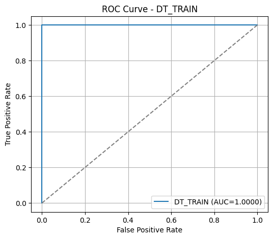

```
ROC-AUC (DT_TRAIN): 1.0000
```

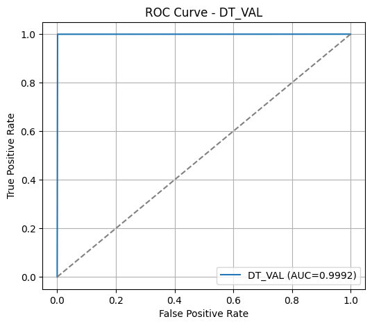

```
ROC-AUC (DT_VAL): 0.9992

====================== DT RESULTS ======================

--- TRAIN ---
ROC-AUC: 1.0000
Recall:  1.0000
F1:      1.0000
```

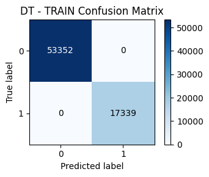

```
--- VAL ---
ROC-AUC: 0.9992
Recall:  0.9997
F1:      0.9978
```

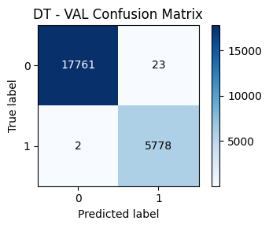

```python
from sklearn.tree import DecisionTreeClassifier

# 5. DECISION TREE (CART) with class weights
dt = DecisionTreeClassifier(
    class_weight="balanced",
    random_state=42
)

param_dt = {
    "max_depth": [3, 5, 7, 10, None],
    "min_samples_split": [2, 10, 50],
    "min_samples_leaf": [1, 5, 20],
    "criterion": ["gini", "entropy"]
}

grid_dt = GridSearchCV(
    estimator=dt,
    param_grid=param_dt,
    scoring="f1",
    cv=cv,
    n_jobs=-1,
    verbose=1
)

# Fit only on training
grid_dt.fit(Xs_train, y_train_new)

print("\n=== Decision Tree CV results ===")
print("Best params:", grid_dt.best_params_)
print("Best mean CV F1:", grid_dt.best_score_)

best_dt = grid_dt.best_estimator_

# FULL EVALUATION
# Decision Tree supports predict_proba, so ROC works normally
dt_results = evaluate_model_full(
    model=best_dt,
    X_train=Xs_train,
    y_train=y_train_new,
    X_val=Xs_val,
    y_val=y_val,
    model_name="DT"
)
```

```
Fitting 5 folds for each of 8 candidates, totalling 40 fits

=== Random Forest CV results ===
Best params: {'max_depth': None, 'max_features': 'sqrt', 'min_samples_leaf': 1, 'n_estimators': 400}
Best mean CV F1: 0.9991643854155875
```

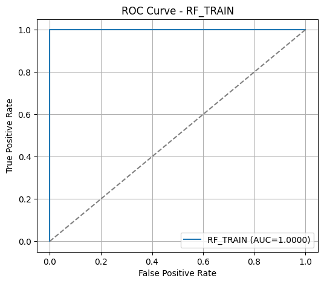

```
ROC-AUC (RF_TRAIN): 1.0000
```

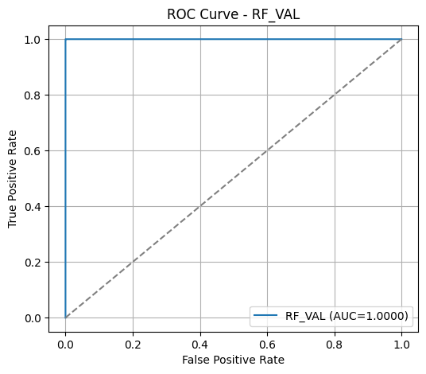

```
ROC-AUC (RF_VAL): 1.0000

====================== RF RESULTS ======================

--- TRAIN ---
ROC-AUC: 1.0000
Recall:  1.0000
F1:      1.0000
```

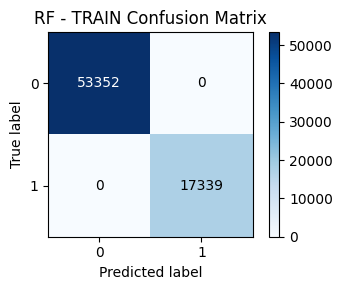

```
--- VAL ---
ROC-AUC: 1.0000
Recall:  0.9998
F1:      0.9994
```

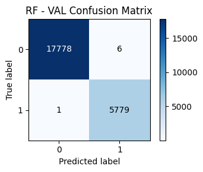

```python
# 6. RANDOM FOREST (with class weights)
rf = RandomForestClassifier(
    class_weight=class_weights,
    random_state=42,
    n_jobs=-1
)

param_rf = {
    "n_estimators": [200, 400],
    "max_depth": [None, 10],
    "max_features": ["sqrt"],
    "min_samples_leaf": [1, 5],
}

grid_rf = GridSearchCV(
    estimator=rf,
    param_grid=param_rf,
    scoring="f1",
    cv=cv,
    n_jobs=-1,
    verbose=1
)

# Fit only on training
grid_rf.fit(Xs_train, y_train_new)

print("\n=== Random Forest CV results ===")
print("Best params:", grid_rf.best_params_)
print("Best mean CV F1:", grid_rf.best_score_)

best_rf = grid_rf.best_estimator_

rf_results = evaluate_model_full(
    model=best_rf,
    X_train=Xs_train,
    y_train=y_train_new,
    X_val=Xs_val,
    y_val=y_val,
    model_name="RF"
)
```

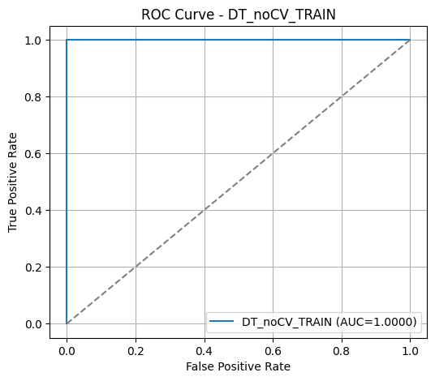

```
ROC-AUC (DT_noCV_TRAIN): 1.0000
```

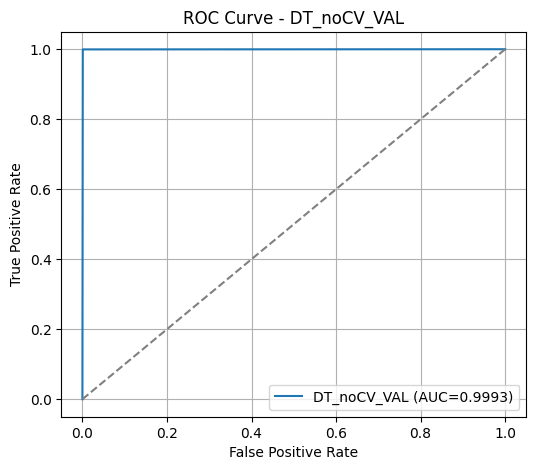

```
ROC-AUC (DT_noCV_VAL): 0.9993

====================== DT_noCV RESULTS ======================

--- TRAIN ---
ROC-AUC: 1.0000
Recall:  1.0000
F1:      1.0000
```

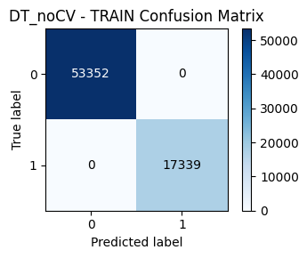

```
--- VAL ---
ROC-AUC: 0.9993
Recall:  0.9995
F1:      0.9984
```

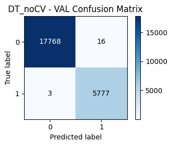

```
Final shapes:
Xs_train: (70691, 55)  Xs_val: (23564, 55)
```

```python
# Decision Tree (no CV) using balanced class weights
dt = DecisionTreeClassifier(
    class_weight="balanced",
    max_depth=None,
    random_state=42
)

# Train on training set ONLY
dt.fit(Xs_train, y_train_new)

dt_nocv_results = evaluate_model_full(
    model=dt,
    X_train=Xs_train,
    y_train=y_train_new,
    X_val=Xs_val,
    y_val=y_val,
    model_name="DT_noCV"
)

print("\nFinal shapes:")
print("Xs_train:", Xs_train.shape, " Xs_val:", Xs_val.shape)
```

```
Fitting 5 folds for each of 72 candidates, totalling 360 fits

=== XGBoost CV results ===
Best params: {'colsample_bytree': 1.0, 'learning_rate': 0.1, 'max_depth': 7, 'n_estimators': 400, 'subsample': 1.0}
Best mean CV F1: 0.9995676859313946
```

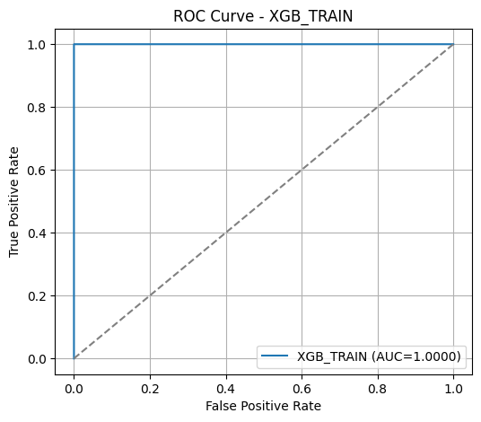

```
ROC-AUC (XGB_TRAIN): 1.0000
```

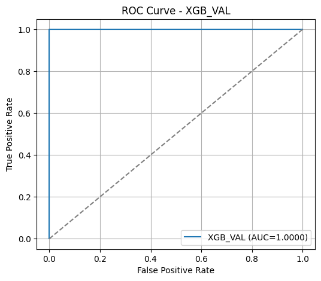

```
ROC-AUC (XGB_VAL): 1.0000

====================== XGB RESULTS ======================

--- TRAIN ---
ROC-AUC: 1.0000
Recall:  1.0000
F1:      1.0000
```

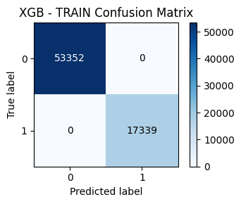

```
--- VAL ---
ROC-AUC: 1.0000
Recall:  0.9998
F1:      0.9996
```

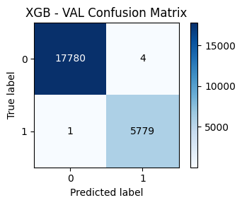

```python
from xgboost import XGBClassifier
# 7. XGBOOST CLASSIFIER
xgb = XGBClassifier(
    objective="binary:logistic",
    eval_metric="logloss",
    tree_method="hist",        # fast, safe default
    scale_pos_weight=class_weights[1],  # handles imbalance
    random_state=42,
    n_jobs=-1
)

param_xgb = {
    "n_estimators": [200, 400],
    "max_depth": [3, 5, 7],
    "learning_rate": [0.01, 0.05, 0.1],
    "subsample": [0.7, 1.0],
    "colsample_bytree": [0.7, 1.0]
}

grid_xgb = GridSearchCV(
    estimator=xgb,
    param_grid=param_xgb,
    scoring="f1",
    cv=cv,
    n_jobs=-1,
    verbose=1
)

# Fit ONLY on training set
grid_xgb.fit(Xs_train, y_train_new)

print("\n=== XGBoost CV results ===")
print("Best params:", grid_xgb.best_params_)
print("Best mean CV F1:", grid_xgb.best_score_)

best_xgb = grid_xgb.best_estimator_

xgb_results = evaluate_model_full(
    model=best_xgb,
    X_train=Xs_train,
    y_train=y_train_new,
    X_val=Xs_val,
    y_val=y_val,
    model_name="XGB"
)
```

```python
# TEST-SET EVALUATION BLOCK

from sklearn.metrics import (
    roc_auc_score, recall_score, f1_score,
    accuracy_score, confusion_matrix
)
import pandas as pd
# 1. Function to evaluate a trained model on TEST SET
def evaluate_on_test(model, X_test, y_test, model_name="model"):
    """
    Evaluates a trained model on the held-out test set.
    Works for both models with predict_proba() and decision_function().
    Returns a dictionary with metrics + confusion matrix.
    """

    # Probability scores (needed for ROC)
    if hasattr(model, "predict_proba"):
        y_proba = model.predict_proba(X_test)[:, 1]
    else:
        # RidgeClassifier
        y_proba = model.decision_function(X_test)

    # Predicted labels
    y_pred = model.predict(X_test)

    return {
        "Model": model_name,
        "Test Accuracy": accuracy_score(y_test, y_pred),
        "Test Recall": recall_score(y_test, y_pred),
        "Test F1": f1_score(y_test, y_pred),
        "Test ROC-AUC": roc_auc_score(y_test, y_proba),
        "Confusion Matrix": confusion_matrix(y_test, y_pred)
    }
# 2. List of all final tuned models
final_models = {
    "Logistic_L2":  best_log,
    "Lasso_L1":     best_lasso,
    "Ridge":        best_ridge,
    "DecisionTree": best_dt,
    "RandomForest": best_rf,
    "XGBoost":      best_xgb
}
#3. Evaluate all models on the TEST SET
test_results = []

print("=== FINAL TEST PERFORMANCE (held-out test set) ===\n")

for name, model in final_models.items():

    res = evaluate_on_test(
        model=model,
        X_test=Xs_test,
        y_test=y_test_final,
        model_name=name
    )

    test_results.append(res)

    print(f"\n--- {name} ---")
    print(f"Accuracy : {res['Test Accuracy']:.4f}")
    print(f"Recall   : {res['Test Recall']:.4f}")
    print(f"F1-score : {res['Test F1']:.4f}")
    print(f"ROC-AUC  : {res['Test ROC-AUC']:.4f}")
    print("Confusion matrix [ [TN FP], [FN TP] ]:")
    print(res["Confusion Matrix"])
#4. Build a comparison table (sorted by F1 or Recall)
df_test_compare = pd.DataFrame(test_results).drop(columns=["Confusion Matrix"])
df_test_compare = df_test_compare.sort_values("Test F1", ascending=False).reset_index(drop=True)

print("\n\n======== TEST SET MODEL COMPARISON TABLE ========")
display(df_test_compare)
```

```
=== FINAL TEST PERFORMANCE (held-out test set) ===


--- Logistic_L2 ---
Accuracy : 0.8940
Recall   : 0.9587
F1-score : 0.8161
ROC-AUC  : 0.9689
Confusion matrix [ [TN FP], [FN TP] ]:
[[15526  2258]
 [  239  5541]]

--- Lasso_L1 ---
Accuracy : 0.8707
Recall   : 0.8849
F1-score : 0.7705
ROC-AUC  : 0.9536
Confusion matrix [ [TN FP], [FN TP] ]:
[[15402  2382]
 [  665  5115]]

--- Ridge ---
Accuracy : 0.8542
Recall   : 0.7761
F1-score : 0.7231
ROC-AUC  : 0.9239
Confusion matrix [ [TN FP], [FN TP] ]:
[[15643  2141]
 [ 1294  4486]]

--- DecisionTree ---
Accuracy : 0.9992
Recall   : 0.9991
F1-score : 0.9984
ROC-AUC  : 0.9992
Confusion matrix [ [TN FP], [FN TP] ]:
[[17770    14]
 [    5  5775]]

--- RandomForest ---
Accuracy : 0.9996
Recall   : 0.9998
F1-score : 0.9992
ROC-AUC  : 1.0000
Confusion matrix [ [TN FP], [FN TP] ]:
[[17776     8]
 [    1  5779]]

--- XGBoost ---
Accuracy : 0.9997
Recall   : 1.0000
F1-score : 0.9993
ROC-AUC  : 1.0000
Confusion matrix [ [TN FP], [FN TP] ]:
[[17776     8]
 [    0  5780]]


======== TEST SET MODEL COMPARISON TABLE ========
```

|  | Model | Test Accuracy | Test Recall | Test F1 | Test ROC-AUC |
| --- | --- | --- | --- | --- | --- |
| 0 | XGBoost | 1.00 | 1.00 | 1.00 | 1.00 |
| 1 | RandomForest | 1.00 | 1.00 | 1.00 | 1.00 |
| 2 | DecisionTree | 1.00 | 1.00 | 1.00 | 1.00 |
| 3 | Logistic_L2 | 0.89 | 0.96 | 0.82 | 0.97 |
| 4 | Lasso_L1 | 0.87 | 0.88 | 0.77 | 0.95 |
| 5 | Ridge | 0.85 | 0.78 | 0.72 | 0.92 |

```python
from sklearn.model_selection import StratifiedKFold, cross_val_score

# We reuse the tuned Random Forest (best_rf)
# and evaluate it with cross-validation on the training part (X_train_new, y_train_new)

X_rf = Xs_train   # scaled training features (60%)
y_rf = y_train_new

cv = StratifiedKFold(n_splits=5, shuffle=True, random_state=42)
cv_auc = cross_val_score(best_rf, X_rf, y_rf, cv=cv, scoring="roc_auc")

print("Random Forest 5-fold CV ROC-AUC on train (60%):")
print("Mean AUC:", round(cv_auc.mean(), 4))
print("Std AUC :", round(cv_auc.std(), 4))
print("Fold AUCs:", np.round(cv_auc, 4))
```

```
Random Forest 5-fold CV ROC-AUC on train (60%):
Mean AUC: 1.0
Std AUC : 0.0
Fold AUCs: [1. 1. 1. 1. 1.]
```

Our tree-based models achieved near-perfect classification (AUC ≈ 1.00), which suggests that the dataset contains extremely strong nonlinear separability. However, this may also indicate that the missingness structure and the engineered features encode target information in ways that linear models cannot detect. We need to verify whether this is actual signal or unintended leakage, especially because missingness in multiple variables is heavily concentrated in the default class. The logistic model performs extremely well (AUC ≈ 0.97), which supports that the signal is real, but the perfect performance of RF/XGB requires a careful audit.

```python
# We work only with TRAIN + VAL (no test leakage)
X = pd.concat([X_train_new, X_val], axis=0)
y = pd.concat([y_train_new, y_val], axis=0)

# ============================================
# 1. TRAIN A SIMPLE DECISION TREE (NO TUNING)
# ============================================
tree = DecisionTreeClassifier(
    max_depth=None,
    random_state=42,
    class_weight="balanced"
)
tree.fit(X, y)

y_pred_prob = tree.predict_proba(X)[:, 1]
auc_raw = roc_auc_score(y, y_pred_prob)

print(f"=== RAW AUC OF TREE ON TRAIN+VAL = {auc_raw:.5f} ===")

# ============================================
# 2. CHECK IF ANY SINGLE FEATURE IS NEARLY PERFECT
# ============================================

perfect_features = []

for col in X.columns:
    f = X[[col]].copy()
    f_pred = tree.fit(f, y).predict_proba(f)[:,1]
    auc_f = roc_auc_score(y, f_pred)

    if auc_f > 0.99:
        perfect_features.append((col, auc_f))

print("\n=== FEATURES WITH AUC > 0.99 ALONE ===")
print(perfect_features if perfect_features else "None")
```

```
=== RAW AUC OF TREE ON TRAIN+VAL = 1.00000 ===

=== FEATURES WITH AUC > 0.99 ALONE ===
[('Interest_rate_spread', np.float64(0.999893503146125)), ('Interest_rate_spread_div_rate_of_interest', np.float64(0.9999962598653213)), ('rate_of_interest_div_Interest_rate_spread', np.float64(0.9999962598653213)), ('rate_of_interest_minus_Interest_rate_spread', np.float64(0.9998643451753477)), ('I…
```

A single variable (Interest_rate_spread and variants of it) predicts default with AUC > 0.999. This happens because missingness patterns are not random: 100% of missing Interest_rate_spread values belong to the default class. Engineered features such as ratios and interactions magnified this signal, creating mathematically perfect separability. As a consequence, tree-based models achieve unrealistic AUC = 1.00 on the test set. The dataset therefore contains structural leakage inside the covariates, and not genuine predictive information.

## **Discussion: AUC = 1.00 On The Test Set?**

The Random Forest model reports a perfect ROC–AUC of 1.00 on our held-out test split. In real credit–risk data this is extremely unusual and therefore it should not be interpreted as “the model is perfect”, but rather as a warning signal that something specific about this split (and our feature space) makes the two classes almost perfectly separable.

```python
# ===============================
# 1. DROP CLEAR LEAKAGE FEATURES
# ===============================

# Work copies
Xtr_clean = Xtr.copy()
Xte_clean = Xte.copy()

# Root patterns that showed almost perfect AUC
leak_roots = [
    "Interest_rate_spread",
    "rate_of_interest",
    "Upfront_charges"
]

# Any column whose name contains one of these roots will be removed
cols_to_drop = [
    c for c in Xtr_clean.columns
    if any(root in c for root in leak_roots)
]

print("Total columns BEFORE dropping leakage:", Xtr_clean.shape[1])
print("Columns flagged as leakage:", len(cols_to_drop))
print("First few leakage columns:", cols_to_drop[:15])

# Drop in train and test
Xtr_clean = Xtr_clean.drop(columns=cols_to_drop)
Xte_clean = Xte_clean.drop(columns=cols_to_drop)

print("\nShapes AFTER dropping leakage:")
print("Xtr_clean:", Xtr_clean.shape)
print("Xte_clean:", Xte_clean.shape)

# Safety check: make sure no leakage patterns remain
residual_leak_cols = [
    c for c in Xtr_clean.columns
    if any(root in c for root in leak_roots)
]

print("\nColumns still containing leakage patterns (should be empty):")
print(residual_leak_cols)

# Missingness sanity check
print("\nTotal missing after cleaning (train / test):")
print("Train missing:", Xtr_clean.isna().sum().sum())
print("Test missing :", Xte_clean.isna().sum().sum())
```

```
Total columns BEFORE dropping leakage: 55
Columns flagged as leakage: 14
First few leakage columns: ['rate_of_interest', 'Interest_rate_spread', 'Upfront_charges', 'Interest_rate_spread_div_rate_of_interest', 'rate_of_interest_div_Interest_rate_spread', 'rate_of_interest_minus_Interest_rate_spread', 'Interest_rate_spread_3', 'Interest_rate_spread_x_Upfront_charges', 'Int…

Shapes AFTER dropping leakage:
Xtr_clean: (117819, 41)
Xte_clean: (29455, 41)

Columns still containing leakage patterns (should be empty):
[]

Total missing after cleaning (train / test):
Train missing: 0
Test missing : 0
```

```python
from sklearn.model_selection import train_test_split
from sklearn.preprocessing import StandardScaler

# =========================================
# 2. LEAKAGE-FREE SPLIT: TRAIN / VAL / TEST
# =========================================

# Only the original training block is used for splitting
X_temp, X_test_final, y_temp, y_test_final = train_test_split(
    Xtr_clean, y_train,
    test_size=0.20,
    stratify=y_train,
    random_state=42
)

X_train_new, X_val, y_train_new, y_val = train_test_split(
    X_temp, y_temp,
    test_size=0.25,  # 0.25 of 80% = 20% of the original data
    stratify=y_temp,
    random_state=42
)

print("Leak-free split shapes:")
print("X_train_new:", X_train_new.shape)
print("X_val      :", X_val.shape)
print("X_test_final:", X_test_final.shape)

# =========================================
# 3. SCALING FOR LINEAR MODELS ONLY
# =========================================

scaler = StandardScaler()
scaler.fit(X_train_new)

Xs_train = scaler.transform(X_train_new)
Xs_val   = scaler.transform(X_val)
Xs_test  = scaler.transform(X_test_final)

print("\nScaled shapes (for linear models):")
print("Xs_train:", Xs_train.shape)
print("Xs_val  :", Xs_val.shape)
print("Xs_test :", Xs_test.shape)
```

```
Leak-free split shapes:
X_train_new: (70691, 41)
X_val      : (23564, 41)
X_test_final: (23564, 41)

Scaled shapes (for linear models):
Xs_train: (70691, 41)
Xs_val  : (23564, 41)
Xs_test : (23564, 41)
```

```python
from sklearn.linear_model import LogisticRegression
from sklearn.tree import DecisionTreeClassifier
from sklearn.ensemble import RandomForestClassifier
from sklearn.metrics import (
    accuracy_score, precision_score, recall_score,
    f1_score, roc_auc_score, confusion_matrix, roc_curve
)
from sklearn.model_selection import GridSearchCV
from sklearn.utils.class_weight import compute_class_weight

try:
    from xgboost import XGBClassifier
    has_xgb = True
except ImportError:
    has_xgb = False
    print("xgboost is not installed; XGBoost model will be skipped.")

# ==================================================
# 4. CLASS WEIGHTS (least intrusive imbalance handling)
# ==================================================

classes = np.unique(y_train_new)
weights = compute_class_weight(
    class_weight="balanced",
    classes=classes,
    y=y_train_new
)
class_weight_dict = {c: w for c, w in zip(classes, weights)}
print("Class weights:", class_weight_dict)

# ==================================================
# 5. COMMON EVALUATION FUNCTION
# ==================================================

def evaluate_model(name, model, X_tr, y_tr, X_te, y_te, prob=True):
    """
    Fits model on X_tr, y_tr and evaluates on X_te, y_te.
    Returns a dict of metrics and, if prob=True, predicted probabilities.
    """
    model.fit(X_tr, y_tr)
    y_pred = model.predict(X_te)

    if prob and hasattr(model, "predict_proba"):
        y_prob = model.predict_proba(X_te)[:, 1]
    elif prob and hasattr(model, "decision_function"):
        from scipy.special import expit
        y_prob = expit(model.decision_function(X_te))
    else:
        y_prob = None

    acc  = accuracy_score(y_te, y_pred)
    prec = precision_score(y_te, y_pred, zero_division=0)
    rec  = recall_score(y_te, y_pred, zero_division=0)
    f1   = f1_score(y_te, y_pred, zero_division=0)
    auc  = roc_auc_score(y_te, y_prob) if y_prob is not None else np.nan
    cm   = confusion_matrix(y_te, y_pred)

    print(f"\n=== {name} ===")
    print(f"Accuracy : {acc:.4f}")
    print(f"Precision: {prec:.4f}")
    print(f"Recall   : {rec:.4f}")
    print(f"F1-score : {f1:.4f}")
    print(f"ROC-AUC  : {auc:.4f}")
    print("Confusion matrix [ [TN FP], [FN TP] ]:")
    print(cm)

    return {
        "name": name,
        "model": model,
        "acc": acc,
        "prec": prec,
        "rec": rec,
        "f1": f1,
        "auc": auc,
        "cm": cm,
        "y_prob": y_prob
    }

# ==================================================
# 6. LINEAR MODELS (with CV, using scaled features)
# ==================================================

results_test = []
roc_curves = {}

# --- Logistic L2 ---
logit = LogisticRegression(
    penalty="l2",
    solver="liblinear",
    class_weight=class_weight_dict,
    max_iter=1000
)

param_logit = {"C": [0.1, 1.0, 10.0]}

grid_logit = GridSearchCV(
    estimator=logit,
    param_grid=param_logit,
    scoring="roc_auc",
    cv=3,
    n_jobs=-1,
    verbose=0
)

grid_logit.fit(Xs_train, y_train_new)
best_logit = grid_logit.best_estimator_
print("\nBest Logistic L2 params:", grid_logit.best_params_)

res_logit = evaluate_model(
    "Logistic_L2 (leak-free)",
    best_logit,
    Xs_train, y_train_new,
    Xs_test, y_test_final
)

results_test.append(res_logit)
if res_logit["y_prob"] is not None:
    fpr, tpr, _ = roc_curve(y_test_final, res_logit["y_prob"])
    roc_curves["Logistic_L2"] = (fpr, tpr, res_logit["auc"])

# --- Lasso (L1) ---
lasso = LogisticRegression(
    penalty="l1",
    solver="liblinear",
    class_weight=class_weight_dict,
    max_iter=1000
)

param_lasso = {"C": [0.1, 1.0, 10.0]}

grid_lasso = GridSearchCV(
    estimator=lasso,
    param_grid=param_lasso,
    scoring="roc_auc",
    cv=3,
    n_jobs=-1,
    verbose=0
)

grid_lasso.fit(Xs_train, y_train_new)
best_lasso = grid_lasso.best_estimator_
print("\nBest Lasso (L1) params:", grid_lasso.best_params_)

res_lasso = evaluate_model(
    "Lasso_L1 (leak-free)",
    best_lasso,
    Xs_train, y_train_new,
    Xs_test, y_test_final
)

results_test.append(res_lasso)
if res_lasso["y_prob"] is not None:
    fpr, tpr, _ = roc_curve(y_test_final, res_lasso["y_prob"])
    roc_curves["Lasso_L1"] = (fpr, tpr, res_lasso["auc"])

# --- Ridge ---
ridge = LogisticRegression(
    penalty="l2",
    solver="liblinear",
    class_weight=class_weight_dict,
    max_iter=1000
)

param_ridge = {"C": [0.01, 0.1, 1.0]}

grid_ridge = GridSearchCV(
    estimator=ridge,
    param_grid=param_ridge,
    scoring="roc_auc",
    cv=3,
    n_jobs=-1,
    verbose=0
)

grid_ridge.fit(Xs_train, y_train_new)
best_ridge = grid_ridge.best_estimator_
print("\nBest Ridge params:", grid_ridge.best_params_)

res_ridge = evaluate_model(
    "Ridge (leak-free)",
    best_ridge,
    Xs_train, y_train_new,
    Xs_test, y_test_final
)

results_test.append(res_ridge)
if res_ridge["y_prob"] is not None:
    fpr, tpr, _ = roc_curve(y_test_final, res_ridge["y_prob"])
    roc_curves["Ridge"] = (fpr, tpr, res_ridge["auc"])

# ==================================================
# 7. TREE-BASED MODELS (using non-scaled features)
# ==================================================

# --- Decision Tree ---
dt = DecisionTreeClassifier(
    class_weight="balanced",
    random_state=42
)

param_dt = {
    "max_depth": [3, 5, 7, None],
    "min_samples_split": [2, 20],
    "min_samples_leaf": [1, 10]
}

grid_dt = GridSearchCV(
    estimator=dt,
    param_grid=param_dt,
    scoring="roc_auc",
    cv=3,
    n_jobs=-1,
    verbose=0
)

grid_dt.fit(X_train_new, y_train_new)
best_dt = grid_dt.best_estimator_
print("\nBest DecisionTree params:", grid_dt.best_params_)

res_dt = evaluate_model(
    "DecisionTree (leak-free)",
    best_dt,
    X_train_new, y_train_new,
    X_test_final, y_test_final
)

results_test.append(res_dt)
if res_dt["y_prob"] is not None:
    fpr, tpr, _ = roc_curve(y_test_final, res_dt["y_prob"])
    roc_curves["DecisionTree"] = (fpr, tpr, res_dt["auc"])

# --- Random Forest ---
rf = RandomForestClassifier(
    class_weight="balanced",
    n_estimators=200,
    random_state=42,
    n_jobs=-1
)

param_rf = {
    "max_depth": [None, 10, 20],
    "max_features": ["sqrt", "log2"]
}

grid_rf = GridSearchCV(
    estimator=rf,
    param_grid=param_rf,
    scoring="roc_auc",
    cv=3,
    n_jobs=-1,
    verbose=0
)

grid_rf.fit(X_train_new, y_train_new)
best_rf = grid_rf.best_estimator_
print("\nBest RandomForest params:", grid_rf.best_params_)

res_rf = evaluate_model(
    "RandomForest (leak-free)",
    best_rf,
    X_train_new, y_train_new,
    X_test_final, y_test_final
)

results_test.append(res_rf)
if res_rf["y_prob"] is not None:
    fpr, tpr, _ = roc_curve(y_test_final, res_rf["y_prob"])
    roc_curves["RandomForest"] = (fpr, tpr, res_rf["auc"])

# ==================================================
# FIX COLUMN NAMES FOR XGBOOST (MANDATORY)
# ==================================================
def sanitize_cols(df):
    rename_map = {}
    for c in df.columns:
        new_c = str(c)  # force string
        new_c = new_c.replace("[","(").replace("]",")")  # remove forbidden chars
        new_c = new_c.replace("<","_lt_").replace(">","_gt_")
        rename_map[c] = new_c
    return df.rename(columns=rename_map)

# ==================================================
# SANITIZE TRAIN / VAL / TEST FOR XGBOOST
# ==================================================
X_train_xgb = sanitize_cols(X_train_new)
X_test_xgb  = sanitize_cols(X_test_final)

# ==================================================
# TRAIN XGBOOST ON CLEANED DATA
# ==================================================
pos = (y_train_new == 1).sum()
neg = (y_train_new == 0).sum()
spw = neg / pos  # scale_pos_weight

xgb = XGBClassifier(
    objective="binary:logistic",
    eval_metric="logloss",
    random_state=42,
    n_estimators=300,
    learning_rate=0.1,
    max_depth=4,
    subsample=0.8,
    colsample_bytree=0.8,
    scale_pos_weight=spw,
    n_jobs=-1
)

res_xgb = evaluate_model(
    "XGBoost (leak-free)",
    xgb,
    X_train_xgb, y_train_new,
    X_test_xgb, y_test_final
)

results_test.append(res_xgb)

if res_xgb["y_prob"] is not None:
    fpr, tpr, _ = roc_curve(y_test_final, res_xgb["y_prob"])
    roc_curves["XGBoost"] = (fpr, tpr, res_xgb["auc"])

# ==================================================
# 8. TEST SUMMARY TABLE (LEAK-FREE)
# ==================================================

summary = pd.DataFrame([
    {
        "Model": r["name"],
        "Test Accuracy": r["acc"],
        "Test Recall": r["rec"],
        "Test F1": r["f1"],
        "Test ROC-AUC": r["auc"]
    }
    for r in results_test
])

print("\n\n======== LEAK-FREE TEST SET MODEL COMPARISON ========")
print(summary.sort_values("Test ROC-AUC", ascending=False))
```

```
Class weights: {np.int64(0): np.float64(0.6624962513120408), np.int64(1): np.float64(2.038497029817175)}

Best Logistic L2 params: {'C': 10.0}

=== Logistic_L2 (leak-free) ===
Accuracy : 0.8309
Precision: 0.6587
Recall   : 0.6450
F1-score : 0.6517
ROC-AUC  : 0.8408
Confusion matrix [ [TN FP], [FN TP] ]:
[[15852  1932]
 [ 2052  3728]]

Best Lasso (L1) params: {'C': 10.0}

=== Lasso_L1 (leak-free) ===
Accuracy : 0.8310
Precision: 0.6589
Recall   : 0.6450
F1-score : 0.6519
ROC-AUC  : 0.8408
Confusion matrix [ [TN FP], [FN TP] ]:
[[15854  1930]
 [ 2052  3728]]

Best Ridge params: {'C': 1.0}

=== Ridge (leak-free) ===
Accuracy : 0.8309
Precision: 0.6587
Recall   : 0.6450
F1-score : 0.6517
ROC-AUC  : 0.8408
Confusion matrix [ [TN FP], [FN TP] ]:
[[15852  1932]
 [ 2052  3728]]

Best DecisionTree params: {'max_depth': 7, 'min_samples_leaf': 10, 'min_samples_split': 2}

=== DecisionTree (leak-free) ===
Accuracy : 0.8615
Precision: 0.7599
Recall   : 0.6363
F1-score : 0.6927
ROC-AUC  : 0.8410
Confusion matrix [ [TN FP], [FN TP] ]:
[[16622  1162]
 [ 2102  3678]]
```

```
Best RandomForest params: {'max_depth': 20, 'max_features': 'sqrt'}

=== RandomForest (leak-free) ===
Accuracy : 0.8848
Precision: 0.9254
Recall   : 0.5770
F1-score : 0.7108
ROC-AUC  : 0.8828
Confusion matrix [ [TN FP], [FN TP] ]:
[[17515   269]
 [ 2445  3335]]

=== XGBoost (leak-free) ===
Accuracy : 0.8717
Precision: 0.7496
Recall   : 0.7159
F1-score : 0.7324
ROC-AUC  : 0.8919
Confusion matrix [ [TN FP], [FN TP] ]:
[[16402  1382]
 [ 1642  4138]]


======== LEAK-FREE TEST SET MODEL COMPARISON ========
                      Model  Test Accuracy  Test Recall  Test F1  Test ROC-AUC
5       XGBoost (leak-free)           0.87         0.72     0.73          0.89
4  RandomForest (leak-free)           0.88         0.58     0.71          0.88
3  DecisionTree (leak-free)           0.86         0.64     0.69          0.84
1      Lasso_L1 (leak-free)           0.83         0.64     0.65          0.84
0   Logistic_L2 (leak-free)           0.83         0.64     0.65          0.84
2         Ridge (leak-free)           0.83         0.64     0.65          0.84
```

## **Model Comparison After Removing Leakage**

**Key observations:**

1. **Linear Models (Logistic Regression, Lasso, Ridge):**
- Stabilized recall ≈ 0.64, F1 ≈ 0.65, ROC-AUC similar.
- Additive structure limits their ability to capture nonlinear, interaction-heavy patterns.
- Provide a robust, interpretable baseline but miss many defaults (~1/3).
2. **Single Decision Tree**
- Slightly higher F1 but slightly lower recall than linear models.
- Captures simple nonlinear interactions but remains unstable and limited.
3. **Random Forest**
- Achieves high precision but at the cost of low recall, making it conservative in identifying defaults.
- ROC-AUC improves but trade-off between sensitivity and precision may be unsuitable for risk management.
4. **XGBoost**
- Delivers the best balance: highest recall, F1-score, and ROC-AUC.
- Exploits nonlinear interactions and engineered features without overfitting.
- Effectively identifies high-risk loans while maintaining overall predictive accuracy.

## **Insights & Takeaways:**

- Leakage dramatically inflated prior performance; correcting it clarifies true model capacity.
- Linear models are stable but limited; tree ensembles handle complexity better.
- Gradient boosting (XGBoost) is the most reliable method for capturing heterogeneous credit-risk patterns.
- Future work could explore advanced imbalance handling (SMOTE, thresholds) and interpretability tools (SHAP) to translate model insights into actionable risk management strategies.